# Finance Theory for Financial Data Science

Mike Aguilar (mike.aguilar@duke.edu)

# Intro

- In this deck, we will cover a few of the topics necessary to understand financial data science. This material is by no means exhaustive in its breadth or depth.
- The expectation is that you have been exposed to most (all?) of this material. As such, this presentation is meant as a reminder as opposed to a first principles introduction.
- We move from **measuring** returns and risk, to **modern portfolio theory**, to **asset pricing**, to **corporate fundamentals**, to **macro drivers** — roughly the order in which these concepts feed into the data science models later in the course.

# Performance Measurement

## Measuring Returns

### Returns are a messy concept

The term “Return” is colloquially abused.

- Net vs Gross
- Simple vs Log
- Realized vs Unrealized
- Price vs Total
- etc…

### Simple (Daily)

Let’s assume $t$ is one day

- 1-Day Net Return (aka Holding Period Yield (HPY)): $R_{t}=\frac{P_{t}-P_{t-1}}{P_{t-1}}=\frac{P_{t}}{P_{t-1}}-1$
- 1-Day Gross Return (aka Holding Period Return (HPR)) ?

### Simple (Multiperiod)

- 2-Day Net: $R_{t}(2)=\frac{P_{t}-P_{t-2}}{P_{t-2}}$
- H-Day Net: $R_{t}(H)=\frac{P_{t}-P_{t-H}}{P_{t-H}}$
- H-Day Gross: ?
- H-Day Gross: ?

### Simple Total Returns (Stocks)

Define $P$ as price and $D$ as dividend and consider $R_{t} = \frac{P_{t}+D_{t}-P_{t-1}}{P_{t-1}}$.

Q: Can you write the Simple Total Return and decompose into two values?

A:

?

### Simple Total Returns (Bonds)

Define $P$ as the price and $C$ as the coupon. Assume purchased at par, such that $P_{t-1}$ equals the face value.

Q: Can you write the Simple Total Return and decompose into two values?

A:

?

### Simple Annualized Returns

Q: What is the meaning of “annualized” return?

A: ?

### Simple Real Returns

Q: What does “Real” mean? Why use?

A:?

Q: How compute real returns?

?

### Shortcoming of Simple Returns

- Simple Returns are not additive
  - returns on monday + tuesday + … + friday does not equal the week’s return
- Simple Returns are not symmetric
  - $100 grown 20% is 120. But 120 shrunk by 20% is 96.
- Our empirical models (e.g. regression) work better with additivity and symmetry
- Log returns are a common solution
  - Sum of daily log returns is weekly log return
  - $100 grown log return 20% and then shrunk 20% brings you back to $100

### From Simple to Log Returns

Let’s focus on daily returns

- $r_{t}=ln(1+R_{t})=ln(P_{t}/P_{t-1}) = ln(P_{t})-ln(P_{t-1})$
- $e^{r_{t}}-1=R_{t}$

### MultiPeriod Log Returns

- $r_{t}(2) = ln(1+R_{t}(2))=ln(P_{t}/P_{t-2})$
- $r_{t}(2) = ln(\frac{P_{t}}{P_{t-1}}\frac{P_{t-1}}{P_{t-2}})$
- $r_{t}(2) = ?$
- $r_{t}(2) = ?$

More generally,

?

### Annualized Log Returns

$r_{t}(H)^{A} = ?$

### Real Log Returns

- $r_{t}^{Real} = r_{t}-\pi_{t}^{C}$
- where $\pi^{C}_{t} = ln(1+\pi_{t})$

### Simple or Log?

- Simple returns are used for performance reporting
- Log returns are used for statistical modeling

## Measuring Risk

### Risk is Difficult to Measure

Q: Why is risk so much more difficult to measure than returns?

A: ?

We will discuss the meaning of risk soon, but for now we proxy with variance and standard deviation.

- $\sigma^{2}_{r_{t}}=\frac{1}{T}\sum_{t=1}^{T}{(r_{t}-\bar{r})^{2}}$
- $\sigma_{r_{t}} = \sqrt{\sigma^{2}_{r_{t}}}$
- Both are commonly referred to as ``volatility”

### Symmetric vs Asymmetric Risk Measures

Q: Is treating upside and downside surprises the same always appropriate?

A: ?

## Risk / Return Measures

### Common Measures of the Risk/Return Tradeoff (SR)

Sharpe Ratio: ?

Q: Meaning? Want high or low?

A:

- Return in excess of risk free per unit of risk ?

### Common Measures of the Risk/Return Tradeoff (Tracking Error)

Tracking Error: $\sqrt{\frac{1}{T-1}\sum_{t=1}^{T}(R^{p}_{t}-R^{B}_{t})^{2}}$, where $R^{p}$ is the portfolio return and $R^{B}$ is the benchmark return.

Q: Meaning? Want high or low?

A:

?

### Other Common Measures

Information Ratio: $IR = \frac{R^{p}-R^{B}}{\text{Tracking Error}}$

? . . .

Sortino Ratio: $\frac{R - R^{f}}{\sqrt{\frac{1}{T}\sum_{t=1}^{T}\left[\min\!\left(0,\; r_t - R^{f}\right)\right]^2}}$

?

## Portfolio Risk and Return

### Portfolio Return

Q: What is the return of a portfolio composed of $N$ assets?

A: ?

### Portfolio Risk

Q: What is the variance of a portfolio composed of $N$ assets?

A:

?

### Portfolio Variance (N=2)

Q: What is the variance of a portfolio of 2 assets?

A:

?

### Portfolio Variance (N=3)

Q: What is the variance of a portfolio of 3 assets?

A:

?

### Curse of Dimensionality

We will compute portfolio return and variance from historical data for peformance reporting. Moreover, we will construct these objects on a prospective basis for portfolio allocation. Let’s assume for now that the weights are known.

Q: How many parameters do we need to estimate portfolio return of N assets?

A: ?

Q: How many parameters do we need to estimate the portfolio variance of N assets?

A: ?

# Modern Portfolio Theory

### What Is Risk?

Q: What is risk, really?

A:

?

### Systematic vs Idiosyncratic Risk

Q: Are all sources of risk equally important to a diversified investor?

A:

?

### Diversification

Q: Why does combining assets reduce risk?

A:

?

### Expected Utility and Risk Aversion

Q: How do we formalize investor preferences over risky outcomes?

A:

?

### Mean-Variance Preferences

Q: When can we summarize preferences using just mean and variance?

A:

?

### The Efficient Frontier

Q: With many risky assets available, which portfolios are “best”?

A:

?

### Adding a Risk-Free Asset

Q: What changes once a risk-free asset is available?

A:

?

### Portfolio Optimization in Practice

Q: How do we solve for optimal weights?

A:

?

# Asset Pricing

## Pricing Risk Free Assets

### Compounding

Q: How much is $100 grown at 5% per year for one year?

A:

?

### Discounting

Q: How much is $105 promised (with certainty) in one year from now worth today?

A:

?

### Coupon Bonds

Q: What is the formula for the PV of a 2yr semi annual coupon bond?

A:

?

### Discount Bond

Q: What is the formula for the PV of a N-yr discount bond?

A:

?

## Asset Market Equilibrium

### Market Risk

- Q: How use exposure to market fluctuations to determine if a stock is over/undervalued? (note: there are several approaches)
- A: ?

### Interpreting the CAPM

Q: What do beta and lambda mean?

A:

?

### The Security Market Line

Q: How do we use CAPM to judge if a stock is over- or under-valued?

A:

?

### Factor Risk

Q: What if a single market factor doesn’t fully explain returns?

A:

?

## Fixed Income

### Duration

Q: How do we measure a bond’s sensitivity to interest rate changes?

A: ?

### Duration Matching

Q: Why do risk managers care about duration?

A:

?

### Yield Curve

Q: Why is the yield curve typically upward sloping?

A:

? .

### Yield Curve Shapes

Q: What does the shape imply?

A:

?

## Equity

### Dividend Discount Model

Q: What is a stock worth?

A: ?

### Gordon Growth Model

Q: What if dividends are expected to grow at a constant rate forever?

A:

?

### P/E Ratio

Q: What is the P/E ratio? How is it measured? How is it used?

A:

?

# Corporate Fundamentals

### Income Statement

Q: What does the income statement measure?

A: ?

### Balance Sheet

Q: What does the balance sheet measure?

A: ?

### Cash Flow Statement

Q: Why do we need a third statement beyond the income statement and balance sheet?

A: ?

### Key Ratios

Q: How do we summarize firm health from these three statements?

A:

**Profitability**

- Gross Margin $=$ ?
- Net Margin $=$ ?
- ROE $=$ Net Income / Equity; ROA $=$ Net Income / Assets

### Key Ratios (continued)

**Liquidity**

- Current Ratio $=$ Current Assets / Current Liabilities
- Quick Ratio $=$ (Current Assets $-$ Inventory) / Current Liabilities

**Leverage**

- Debt/Equity $=$ Total Debt / Equity
- Interest Coverage $=$ EBIT / Interest Expense

**Efficiency**

- Asset Turnover $=$ Revenue / Assets
- Inventory Turnover $=$ COGS / Average Inventory

# Macro Drivers

### Macro KPI

Q: What are the 4 major macro KPIs?

A:

?

### Connecting the KPIs

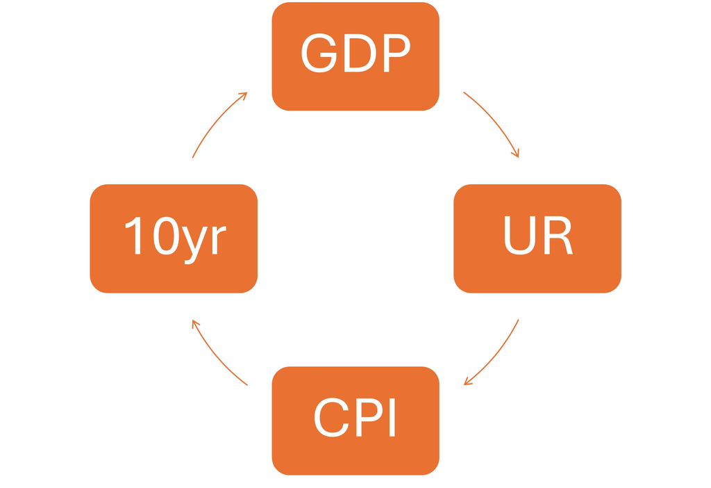

### Explaining the Connections

Q: Can you theoretically connect the Macro KPIs?

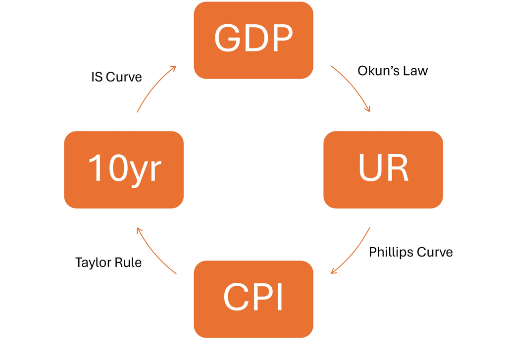

### Okun’s Law

Q: What does Okun’s Law capture?

A:

?

### The Phillips Curve

Q: What tradeoff does the Phillips Curve describe?

A:

?

### The Taylor Rule

Q: How do central banks set the policy rate, in theory?

A:

?

### The IS Curve

Q: What does the IS curve capture?

A:

?

### Business Cycles

Q: What are the phases of a business cycle, and how long does one typically last?

A:

?

# From Theory to Financial Data Science

### Why This Review Matters for the Course

- Log returns $\rightarrow$ the natural scale for time-series models (stationarity, additivity)
- Risk/covariance models $\rightarrow$ inputs to portfolio optimization, VaR, and ML-based risk models
- Factor models $\rightarrow$ feature engineering for return prediction and risk attribution
- Discounting & duration $\rightarrow$ scenario analysis and cash-flow forecasting under rate/macro shocks
- Financial statements & ratios $\rightarrow$ structured features for credit-risk and corporate-forecasting models
- Business cycle & macro drivers $\rightarrow$ the conditioning variables behind any scenario or stress-testing exercise